# Dissertation Analysis

### Q: Is there exciting variation among the *Collection_rate_correct_item* that will help me understand the influence of the feedback condition?

I want to examine the distribution of collection rates.

$$Collection Rate for Correct Items (Team) = \frac{duration_{Team}}{total.correct.items.collected_{Team}}$$

Where $duration_{Team}$ is the amount of time the group spent completing the task and $total.correct.items.collected_{Team}$ is the total number correct items (individual or team items) collected by the group.

$$Collection Rate for Correct Items (Individual) = \frac{duration_{Individual}}{total.correct.items.collected_{Individual}}$$

Where $duration_{Individual}$ is the amount of time the indvidiaul spent completing the task and $total.correct.items.collected_{Individual}$ is the total number correct items (individual or team items) collected by the individual.

I divided the duration by the number of items to collect because dividing the total correct items collected by the duration has hard to interpret.

Note: It is important to remember that a high performing team would have a lower collection rate.

#### Team

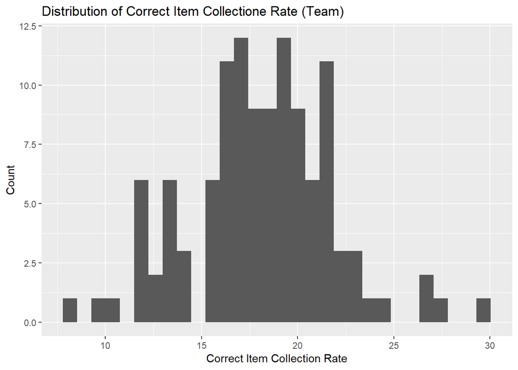

```r
dependent_response_team <- "Collection_rate_correct_item_team"
y_label_team <- "Count"
x_label_team <- "Correct Item Collection Rate"
title_response_team <- "Distribution of Correct Item Collectione Rate (Team)"

# Plot location
setwd(figure_directory)

plot_data_team <- team_data %>%
  select(dependent_response_team)

ggplot(data = plot_data_team) +
  geom_histogram(aes_string(x = dependent_response_team), bins = 30) +
  labs(title = title_response_team, x = x_label_team, y = y_label_team) +
  ggsave("Histogram_CollectionRateCorrect_Team.png")
```

The distribution tells me that most groups had a correct item collection rate of about 20 sec per correct item. In other words, group generally needed about 20 secs to collect a correct items.

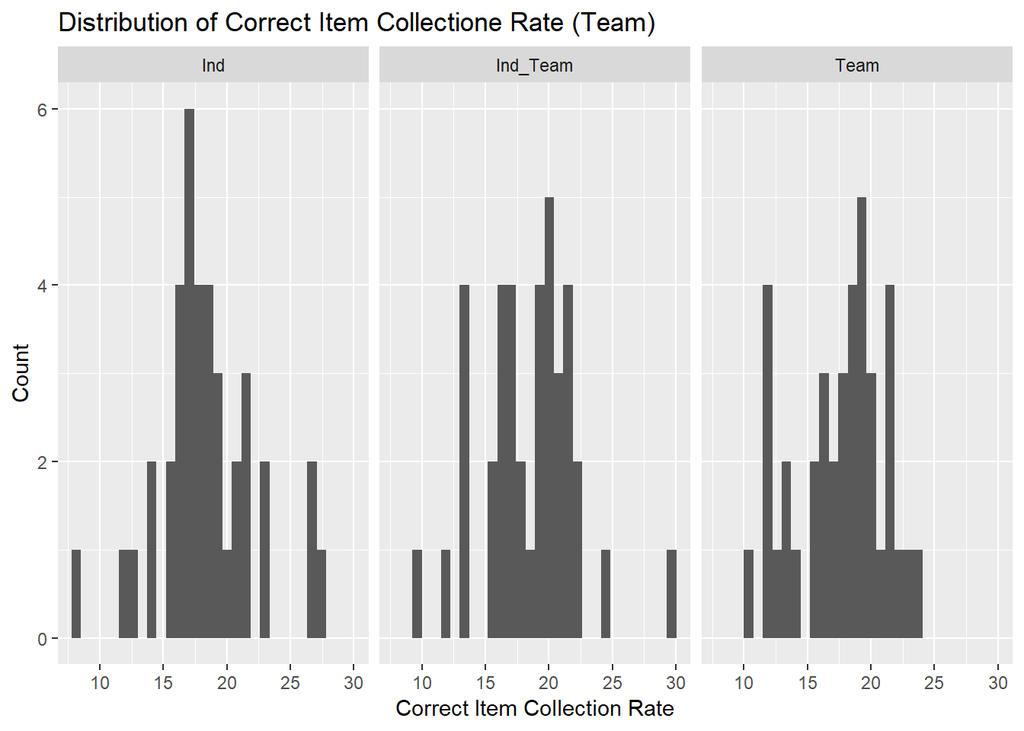

```r
dependent_response_team <- "Collection_rate_correct_item_team"
y_label_team <- "Count"
x_label_team <- "Correct Item Collection Rate"
title_response_team <- "Distribution of Correct Item Collectione Rate (Team)"

# Plot Location
setwd(figure_directory)

plot_data_team <- team_data %>%
  select(dependent_response_team, Target)

ggplot(data = plot_data_team) +
  geom_histogram(aes_string(x = dependent_response_team), bins = 30) +
  facet_grid(. ~ Target) +
  labs(title = title_response_team, x = x_label_team, y = y_label_team) +
  ggsave("Histogram_CollectionRateCorrect_ByTarget_Team.png")
```

```r
# Information about the N values in each condition
tableData <- team_data %>%
  group_by(Target) %>%
  summarise(N = length(.data[[dependent_response_team]]))

tableData %>%
  kable() %>%
  kable_styling()
```

| Target | N |
| --- | --- |
| Ind | 39 |
| Ind_Team | 39 |
| Team | 39 |

The plot tells me that the distribution in the feedback conditions is similar to the distribution overall. However, it does look like the correct item collection rate is slightly higher in the Team condition when compared to the Ind condition. The slight increase in the center (i.e., average) tells me that the groups needed more time to collect the correct items in the Team condition.

#### Individual

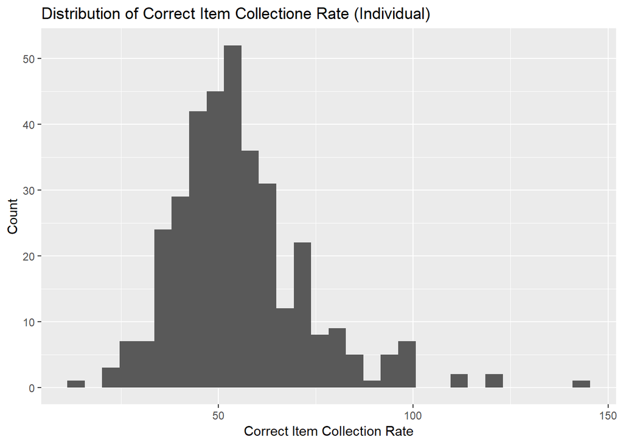

```r
dependent_response_ind <- "Collection_rate_correct_item_ind"
y_label_ind <- "Count"
x_label_ind <- "Correct Item Collection Rate"
title_response_ind <- "Distribution of Correct Item Collectione Rate (Individual)"

# Plot Location
setwd(figure_directory)

plot_data_ind <- ind_data %>%
  select(dependent_response_ind)

ggplot(data = plot_data_ind) +
  geom_histogram(aes_string(x = dependent_response_ind), bins = 30) +
  labs(title = title_response_ind, x = x_label_ind, y = y_label_ind) +
  ggsave("Histogram_CollectionRateCorrect_Ind.png")
```

The distribution plot tells me that the collection rate for most individuals is around 50 second per correct item collected. This collection rate is higher than the collection rate of the team as a whole. This higher collection rate tells me that individuals needed more time to collect correct items. The collection rate at the individual level is higher than the team level makes sense because at the team level there are more people collecting items.

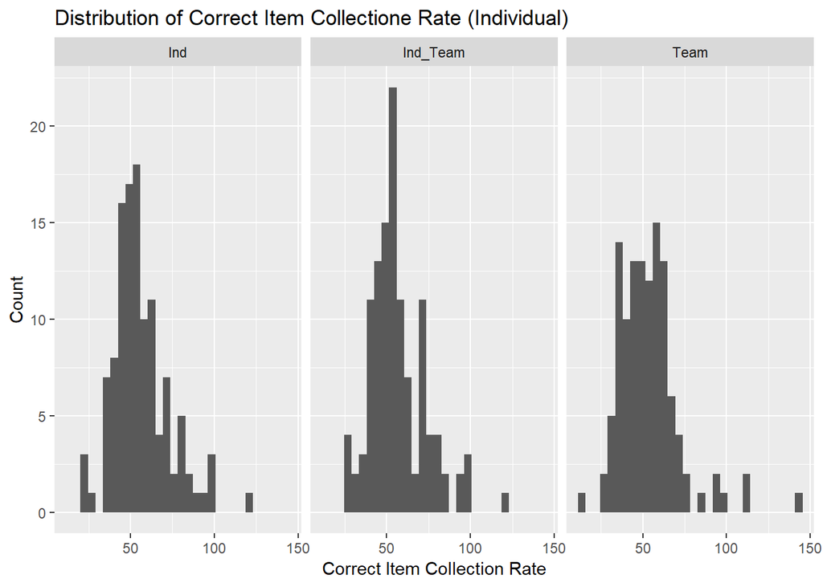

```r
dependent_response_ind <- "Collection_rate_correct_item_ind"
y_label_ind <- "Count"
x_label_ind <- "Correct Item Collection Rate"
title_response_ind <- "Distribution of Correct Item Collectione Rate (Individual)"

# Plot Location
setwd(figure_directory)

plot_data_ind <- ind_data %>%
  select(Target, dependent_response_ind)

ggplot(data = plot_data_ind) +
  geom_histogram(aes_string(x = dependent_response_ind), bins = 30) +
  facet_grid(. ~ Target) +
  labs(title = title_response_ind, x = x_label_ind, y = y_label_ind) +
  ggsave("Histogram_CollectionRateCorrect_ByTarget_Ind.png")
```

```r
# Information about the N values in each condition
tableData <- ind_data %>%
  group_by(Target) %>%
  summarise(N = length(.data[[dependent_response_team]]))

tableData %>%
  kable() %>%
  kable_styling()
```

| Target | N |
| --- | --- |
| Ind | 117 |
| Ind_Team | 117 |
| Team | 117 |

#### Summary / Reflection

At the team level, most teams needed about 20 seconds on average to collect a correct team item. The center of the distrabutions when seperated by Target are roughly similar. The centers were also hovering around 20 for each distribution.

At the individual level, most participants needed about 50 seconds to collect a correct item. When I group the data by Target levels, the distribution is similar to the overall distrubution.

How does the session order influence the collection rate distibution?

The next step is to see how the distrabutions look when the data is group by Target and Session Order.

## The section below is for the collection rate for correct items. Still nees work XXXXXXXXXXXXXXXXXXXXXXXXXXXXXXXXXXXXXXX

### Q: Is there exciting variation among the *Collection_rate_correct_item* that explains how the feedback conditions influence the time remaining when session order is taken into consideration?

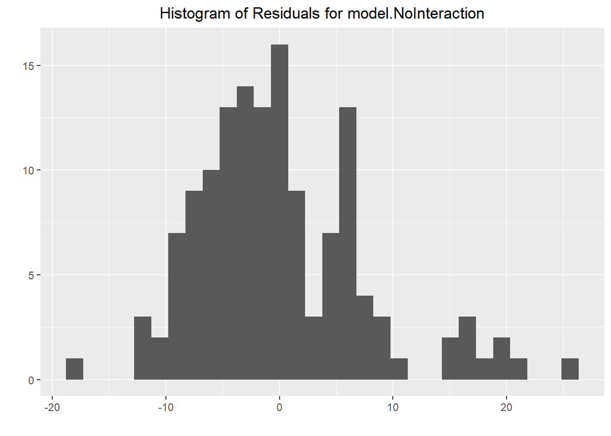

```r
# Data to model
data_modified_ind <- ind_data %>%
  select(Collection_rate_correct_item_ind,
         Target,
         SessionOrder,
         Team,
         Player_ID,
         Dominate.Strategy) %>%
  filter(Dominate.Strategy == "Go Together")

# Plot location
setwd(figure_directory)

# Generate models with variable response
response_variable <- "Collection_rate_correct_item_ind"
data_focus_ind <- data_modified_ind
model.NoInteraction <- model_data_Target_Session(df = data_focus_ind, dependent =  response_variable, model.type =  "NoInteraction", is.team = FALSE, is.robust = FALSE)

# Histogram of Residuals - model.NoInteraction
ggplot(model.NoInteraction, aes(x = .resid)) +
  geom_histogram(bins = 30) +
  labs(title = paste("Histogram of Residuals for model.NoInteraction"), x = "", y = "") +
  theme(plot.title = element_text(hjust = 0.5)) +
  ggsave("Histogram_Residuals_TimeRemaining_NoInteraction_Ind.png")
```

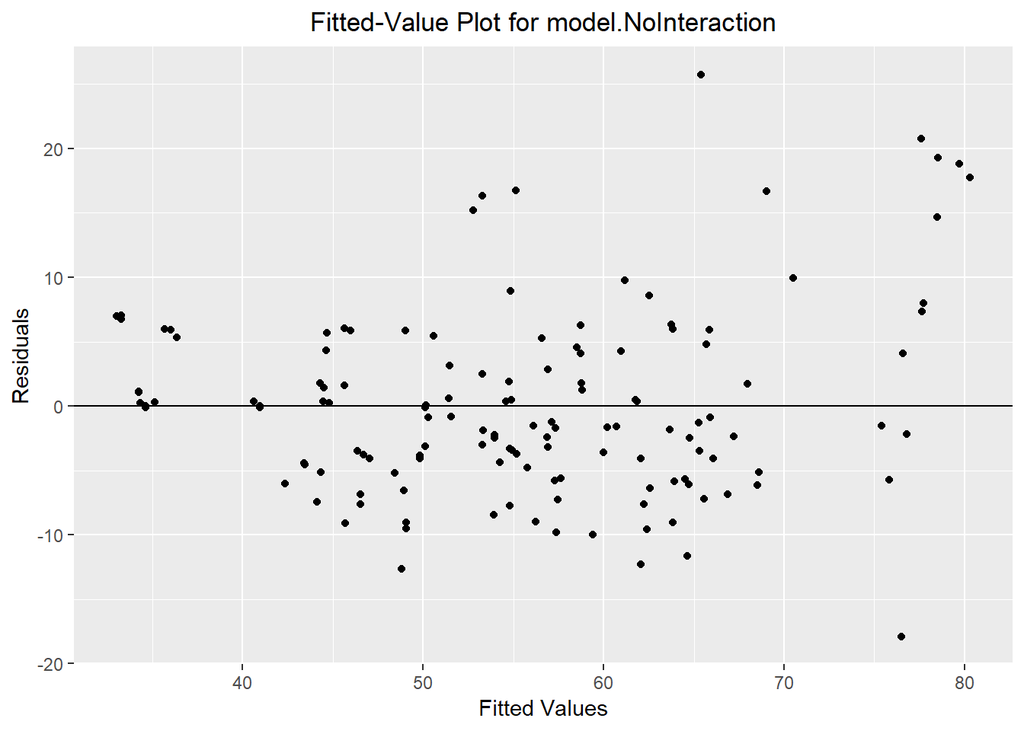

```r
# Fitted values - model.NoInteraction
ggplot(model.NoInteraction, aes(x = .fitted, y = .resid)) +
  geom_point() +
  geom_hline(yintercept = 0)+
  labs(title = paste("Fitted-Value Plot for model.NoInteraction"), x = "Fitted Values", y = "Residuals") +
  theme(plot.title = element_text(hjust = 0.5)) +
  ggsave("FittedValue_Residuals_TimeRemaining_NoInteraction_Ind.png")
```

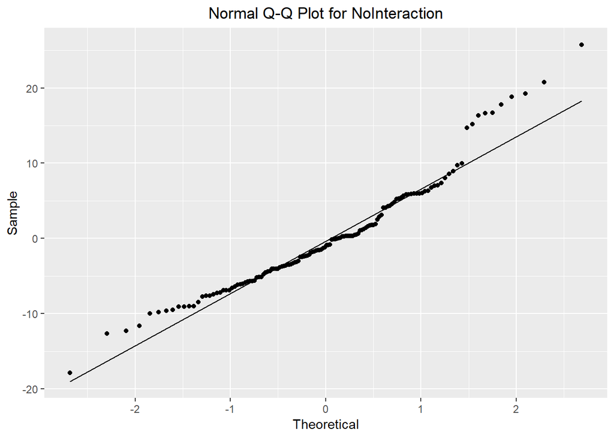

```r
# QQ plots - model.NoInteraction
ggplot(model.NoInteraction, aes(sample = .resid)) +
  stat_qq() +
  stat_qq_line()+
  labs(title = "Normal Q-Q Plot for NoInteraction", x = "Theoretical", y = "Sample") +
   theme(plot.title = element_text(hjust = 0.5)) +
  ggsave("QQ_Residuals_TimeRemaining_NoInteraction_Ind.png")
```

```r
summary(model.NoInteraction)
```

```
## Linear mixed model fit by REML. t-tests use Satterthwaite's method [
## lmerModLmerTest]
## Formula:
## as.formula(paste(dependent, "~ Target + SessionOrder + (1|Team) + (1| Player_ID)"))
##    Data: df
##
## REML criterion at convergence: 1007.3
##
## Scaled residuals:
##     Min      1Q  Median      3Q     Max
## -2.1840 -0.6151 -0.1289  0.5275  3.1432
##
## Random effects:
##  Groups    Name        Variance Std.Dev.
##  Player_ID (Intercept)   6.145   2.479
##  Team      (Intercept) 119.912  10.950
##  Residual               67.175   8.196
## Number of obs: 138, groups:  Player_ID, 54; Team, 18
##
## Fixed effects:
##                Estimate Std. Error      df t value Pr(>|t|)
## (Intercept)      67.781      3.065  26.198  22.115  < 2e-16 ***
## TargetInd_Team   -1.485      1.791  81.794  -0.829  0.40934
## TargetTeam       -5.408      1.876  83.937  -2.883  0.00501 **
## SessionOrder3    -9.037      1.899  82.678  -4.759 8.16e-06 ***
## SessionOrder4   -14.302      1.893  83.816  -7.555 4.72e-11 ***
## ---
## Signif. codes:  0 '***' 0.001 '**' 0.01 '*' 0.05 '.' 0.1 ' ' 1
##
## Correlation of Fixed Effects:
##             (Intr) TrgI_T TrgtTm SssnO3
## TargtInd_Tm -0.226
## TargetTeam  -0.231  0.542
## SessinOrdr3 -0.283 -0.196 -0.162
## SessinOrdr4 -0.295 -0.166 -0.187  0.611
```

```r
emmeans(model.NoInteraction, list(pairwise ~ Target), adjust = "tukey")
```

```
## $`emmeans of Target`
##  Target   emmean   SE   df lower.CL upper.CL
##  Ind        60.0 2.91 21.3     54.0     66.0
##  Ind_Team   58.5 2.89 20.9     52.5     64.5
##  Team       54.6 2.91 21.5     48.5     60.6
##
## Results are averaged over the levels of: SessionOrder
## Degrees-of-freedom method: satterthwaite
## Confidence level used: 0.95
##
## $`pairwise differences of Target`
##  contrast        estimate   SE   df t.ratio p.value
##  Ind - Ind_Team      1.49 1.79 81.8 0.829   0.6860
##  Ind - Team          5.41 1.88 83.9 2.883   0.0137
##  Ind_Team - Team     3.92 1.76 81.6 2.233   0.0717
##
## Results are averaged over the levels of: SessionOrder
## P value adjustment: tukey method for comparing a family of 3 estimates
```

# References

Field, A. P., & Wilcox, R. R. (2017). Robust statistical methods: A primer for clinical psychology and experimental psychopathology researchers. *Behaviour Research and Therapy*, *98*, 19–38. https://doi.org/10.1016/j.brat.2017.05.013

Galwey, N. W. (2014). Testing the assumptions of the analyses: Inspection of the residual values. In *Introduction to mixed modelling: Beyond regression and analysis of variance* (Second). Chichester, United Kingdom: John Wiley & Sons, Ltd.

Johnson, P. C. (2014). Extension of Nakagawa & Schielzeth’s R 2 GLMM to random slopes models. *Methods in Ecology and Evolution*, *5*(9), 944–946. https://doi.org/10.1111/2041-210X.12225

Koller, M. (2016). robustlmm : An R Package for Robust Estimation of Linear Mixed-Effects Models. *Journal of Statistical Software*, *75*(6). https://doi.org/10.18637/jss.v075.i06

Nakagawa, S., & Schielzeth, H. (2013). A general and simple method for obtaining R 2 from generalized linear mixed-effects models. *Methods in Ecology and Evolution*, *4*(2), 133–142. https://doi.org/10.1111/j.2041-210x.2012.00261.x

Tukey, J. W. (1977). *Exploratory data analysis*. Reading, Mass.: Addison-Wesley Pub.